# Investigating Politics

February 26, 2018

## Measurement

## Recap

### Concept

### \(\xrightarrow{}\)

### Variable

- Something **observable** that captures/maps onto concept

### \(\xrightarrow{}\)

### Measure:

- Procedure for observing the variable

## Concept to Measurement:

### Concept:

- An **abstract** definition for characteristics of or types of phenomena, groups, or individuals.

### Variable:

A **measurable property** of a phenomena, group, or individual that takes on different values (it *vari*es). Maps onto a concept.

### Measure:

A **procedure** for determining the value of a variable for **specific cases** based on **observation**.

## Concept to Measurement: Concepts

**dimensions of a concept**: phenomena that both:

1. Are **part** of the concept
2. Could exist, disappear, change **independently** of one another. They are **not redundant**

## Concept to Measurement: Variables

### Levels of Measurement:

- Nominal
- Ordinal
- Interval
- Ratio

### Choices:

- Absolute levels
- Relative levels

## Testing Claims:

### Causal Theory vs. Causal Claim

- Concepts \(\xrightarrow{}\) Variables
  - Independent (Cause) and Dependent (Outcome) Variables
- Direction of effect
- Causal logic

## But how do we decide what measurement to use?

## Examples

## Political Knowledge:

### Democracy:

- Does democratic governance require that citizens have sufficient knowledge to make decisions?

### What might they need to know?

- What are government policies?
- What policies do parties/candidates support?
- What are effects of various policies on their (citizen's) interests?

## Political Knowledge:

What do people actually know?

## Political Knowledge:

Does the kind of knowledge required for democracy correspond to questions about current events, institutional rules of government?

### Two measures:

- Survey people on factual questions; more correct answers mean more knowledge
- Interviewer talks with person for a two hours, then rates their knowledge.

## Racial Bias in Police Shootings

Recent renewal of long-standing controversy:

### Is police/government violence in the US biased against African Americans?

### How would we know?

One way is to think of "statistical discrimination":

- Are African Americans treated differently to white Americans in otherwise identical situations?
- Requires measuring things like "objective threat" to a police officer posed by a suspect

## Racial Bias in Police Shootings

How do we measure "objective threat" in a civilian-police officer interaction?

## Guns

### Gun Control vs Self Defense

Many argue that guns provide a means of self-defense and can deter crime

### Measurement

How would we measure whether this occurs?

## Guns

### Survey people

Ask about their use of firearms, ask if they use in self-defense, then obtain details to clarify whether it was in fact a use of a firearm in a situation with another person.

Ask about whether these incidents occurred during criminal actions

## Problems

## Measurement Trouble

### Validity

**validity of a measure**:

- Degree of fit between a measurement procedure for a variable, and the concept that the variable is intended to capture
- How well as measure "captures" or "maps onto" the concept

## Measurement Trouble

### Threats to validity

Validity can break down in two places:

1. Concept \(\xrightarrow{Mismatch}\) Variable
2. Variable \(\xrightarrow{Mismatch}\) Measure

## Measurement Trouble

### Threats to validity

1. Measure does not cover **enough**s of the concept:
   - Measure only captures some but not all relevant **dimensions** of the concept

## Measurement Trouble

**Concept**: Political knowledge needed for democratic citizen

**Variable**: Recall of factual questions about current politicians, political parties

**Measure**: Survey containing a list of factual questions

### Factual recall may not capture all of the kinds of knowledge that is relevant

- Knowing you and all of your neighbors lost their jobs and are struggling might be enough information to vote against incumbent
- Breakdown at Concept/Variable

## Measurement Trouble

**Concept**: Political Participation in Democracy

**Variable**: Frequency with which a person participates in political activity

**Measure**: Survey containing questions about frequency of voting in elections

### Voting may not be the only kind of political activity that is relevant

- Working on campaigns, protesting, writing to representatives could also be participation
- Breakdown at Variable/Measure

## Measurement Trouble

### Threats to validity

1. Measure does not cover **enough** of the concept:
   - Measure only captures some but not all relevant **dimensions** of the concept
2. Measure covers things **outside** the concept:
   - Could cover somethings inside the concept, or **nothing** inside the concept

## Measurement Trouble

**Concept**: Political knowledge needed for democratic citizen

**Variable**: Level of perceptiveness about politics and political issues

**Measure**: Survey where interviewer rates respondent after questions and discussion.

### Interviewer may bring in things outside of "political knowledge" when rating

- Respondent's verbal skills/ agreement between interviewer and respondent
- Breakdown at Variable/Measure

## Measurement Trouble

**Concept**: Self Defense Gun Use

**Variable**: Event where person deters crime using a firearm

**Measure**: Survey where people report their use of firearms to deter crimes

### People may be bad at reporting their use of guns

- Respondents perceive crimes that are not there (people actually use their weapons to threaten others)
- Respondents inflate their ego by exaggerating threat (estimated 400,000 murders prevented by firearms annually)
- Breakdown at Variable/Measure

## Measurement Trouble

**Concept**: Political Corruption

**Variable**: Rate of corruption among individual politicians in a place

**Measure**: Rate of corruption prosecutions among politicians in a place

### Does this capture **anything** inside the concept?

- Places with lots of corruption do not prosecute corruption
- Places with low corruption successfully prosecute corruption
- Breakdown at Variable/Measure

## Measurement Trouble

**Concept**: Framing/Racial Priming of government social programs

**Variable**: Portrayal of social programs as "Welfare" or "Assistance to the Poor"

**Measure**: Survey people on support for "welfare" or "assistance to the poor"

### Does this capture the concept?

- "Welfare" might have racial connotation in the US.
- But, people actually think of different policies when asked about "welfare" and "assistance to the poor".
- Variable captures both framing AND policy preferences.
- Breakdown at Concept/Variable

## Measurement Trouble

**Concept**: Racism

**Variable**: Opposition to having neighbor of a different race

**Measure**: Survey people on opposition to having a neighbor of a different race

### Does this capture the concept?

- People are unlikely to be truthful: desirability bias
- Breakdown at Variable/Measure

## Measurement Trouble:

### List Experiments?

> "I am going to read ou a list of things that sometimes make people angry, after I read them just tell me HOW MANY of them upset you. I don't want to know which ones."

## Measurement Trouble

1. Increase in gasoline tax
2. Professional athletes with multi-million $ contract
3. Large industrial corporations polluting
4. Construction of high-rise in your neighborhood
1. Increase in gasoline tax
2. Professional athletes with multi-million dollar contract
3. Large industrial corporations polluting
4. Black family moving in next door

## Measurement Trouble

### Threats to validity

1. Measure does not cover **enough** of the concept:
   - Measure only captures some but not all relevant **dimensions** of the concept
2. Measure covers things **outside** the concept:
   - Could cover somethings inside the concept, or **nothing** inside the concept
   - Measure of concept cannot be a **cause** or an **effect** of the concept
3. Measure captures different things across units: **non-comparability**

## Measurement Trouble

**Concept**: Objective threat to police

**Variable**: Possession of a weapon by suspect

**Measure**: Reported possession of weapon in police officer report after Officer Involved Shooting

### Does this capture the concept?

- Police might report item as a weapon differently in case of black vs. white suspect
- Measurement is not the same across units
- Breakdown at Variable/Measure

## Measurement Trouble

**Concept**: Exposure to political information

**Variable**: Frequency of reading a newspaper

**Measure**: Survey of people asking for frequency with which they read a newspaper

### Does this capture the concept?

- If we want to compare exposure to political information over time, this could be a problem
- In the 1940s/1950s, newspapers major source of information, but now televisiona nd internet more common.
- Breakdown at Concept/Variable

## Measurement Trouble

### Reliability

**reliability of a measure**:

- How consistently a measurement procedure produces the same result, when repeated for the same case
  - If two researchers use same procedure, do they get the same result?

## Reliability vs Validity

[figure not shown]

## Reliability vs Validity

### Measuring Individual Income:

|  | **Less Valid** | **More Valid** |
| --- | --- | --- |
| **Less Reliable** | Are you high, middle, or low income? | What is your annual income? |
| **More Reliable** | What is the make and model of your car? | Tax Records |

## Measurement Trouble

### Threats to Reliability

1. Room for researcher **interpretation**. **Imprecise** procedures for measurement
   - Expert Ratings (e.g. democracy)
   - Assessing motives (e.g. Donald Trump and "Muslim ban")
   - Assessing motives (e.g. Police shootings)

## Measurement Trouble

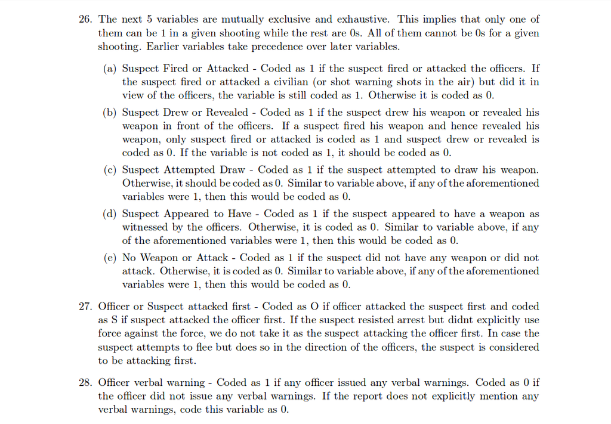

## Measurement Trouble

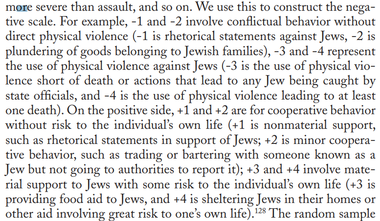

## Measurement Trouble

### Threats to Reliability

1. Room for researcher **interpretation**. Imprecise procedures for measurement
   - Expert Ratings (e.g. democracy)
   - Assessing motives (e.g. Donald Trump and "Muslim ban")
   - Assessing motives (e.g. Police shootings)
2. **Instability**: measurement may be unstable over time, even when underlying phenomenon is stable.
   - People's responses to interview questions change
   - Survey response can change due to "randomness": memory/recall, different circumstances
   - Repeated measures can help

## Measurement Trouble

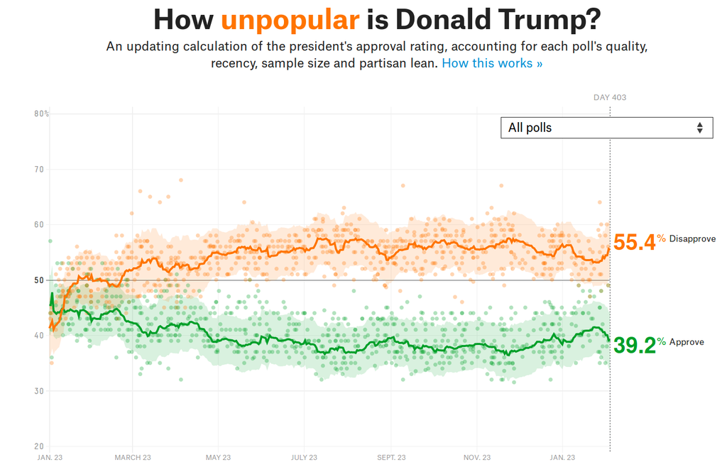

## Measurement Error

## Measurement Error

Weak **validity** or **reliability** \(\xrightarrow{}\) **measurement error**

### Two Varieties

1. One type is mostly harmless
2. The other is a problem

## Measurement Error

### Bias

**bias** or **systematic error**: error produced when our measurement procedure obtains scores that are, on average, too high or too low.

- can have an *upward* or *downward* bias
- "on average": even if you repeat the measurement, the tendency is toward a value that is too high or too low
- **not** "politically" biased
- bias (measuring too high or too low) might be all cases or just for certain subgroups

## Measurement Error

### Random Measurement Error

**random error**: Error derivces from random features of measurement process or phenomenon

- Because of chance, we get a value that is too high or too low
- There is not systematic tilt one way or another

## Measurement Error

### Random vs. Bias

|  | **Bias** | **Random Error** |
| --- | --- | --- |
| **Attribute** | Validity | Reliability |
| **Pattern** | Related to another concept | Unrelated to other concept; related to unrelated concept |
| **Testing Causal Theory** | Unknown change in results; hard to fix | Find no relationship even if there is one |
| **When it's OK** | If it is UNIFORM across cases | If false negative better than false positive |

## Measurement Error

### Random vs. Bias

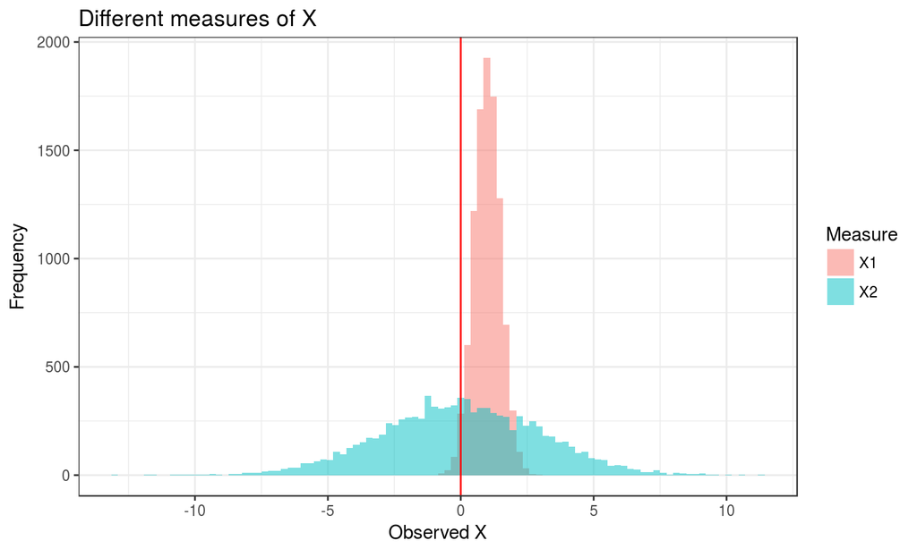

## Measurement Error

### \(X1\) is *biased*

### \(X2\) has *random error*

## Random Error vs. Bias

[figure not shown]

## Bias

### Sources

1. Researcher subjectivity/interpretation
   - Researcher systematically over-weights, under-weights dimension of concept

## Example

### Political Knowledge

Overweighting verbal skills in measure of political knowledge

\(\xrightarrow{DownwardBias}\) political knowledge of less articulate respondents

## Bias

### Sources

1. **Gap** between concept and measure
- Measure things **outside**/extraneous to the concept
  - Upward bias for cases with extraneous features
  - Downward bias for cases without extraneous features
  - e.g. Survey on self-defense gun use gives upward bias for people who are paranoid
- Fail to measure things **inside** the concept:
  - Upward bias for cases that lack missing dimensions
  - Downward bias for cases that have missing dimensions

## Bias

### Sources

1. **Obstacle to observation**
   - **social norms** may discourage revelation of information; downward bias in "undesirable" phenomena
   - e.g. survey measure of racism or drug use \(\xrightarrow{}\) **social desirability bias**

## Bias

### Sources

1. **Obstacle to observation**
   - **incentives to hide/misrepresent**: political actors have strategic reasons to conceal information from each other
   - e.g. states may present their military capacity to be better than it is (upward bias)
   - e.g. wealthy people may present themselves as less wealthy to avoid negative attention (downward bias)

## Bias

### Sources

1. **Obstacle to observation**
   - **anticipated reactions**: political actors anticipate what others will do. They don't pick fights they will use.
   - e.g. Measure what Trudeau wants on policy by looking at his proposed legislation
   - e.g. Measure opposition to dictator using public protest
   - Downward bias for actions likely to be unsuccessful.

## Bias: Solutions?

1. Researcher subjectivity:
   - More precise, clear rules for measurement procedure
2. **Gap** between concept and measure
   - Adjust measure to fit concept
   - Use multiple measures that miss **different** parts of concept
3. Obstacles to observation:
   - Social norms: Protect anonymity, subtle measurement (list experiment)
   - Incentives to hide/misrepresent: use private records, behavior not statements, interview after incentives gone
   - Anticipated reactions: protect anonymity, subtle measurement, examine less costly behaviors

## Random Error

### Sources

- Imperfect memory (survey/interviews)
- "Random" changes in mood/concerns (for surveys)
  - e.g. rain might make you more angry and support government less
- Counting errors (e.g., national statistics)
- Researcher interpretation
  - e.g. random differences in classifying cases

## Random Error

If truly random: errors **cancel out** with many trials

### Solutions

- Repeat measure for lots of cases/individuals
- Repeat measure for same case at multiple points in time
- Have multiple researchers apply measure to same case

## Bias

Because it is **not** random:

- Repeating measurement does not help

Instead:

- Improve the measurement procedure
- Use **multiple** measures with different problems:
  - Upward bias in measure 1 may be balanced by downward bias in measure 2
  - Ideally, measures from entirely different sources

## Rule of Thumb:

### "Truth lies at the confluence of *independent* streams of evidence"

- Karl Deutsch

## Too much to measure?

## Gun Control:

[figure not shown]

## Gun Control:

[figure not shown]

## Can't interview *everybody*

### Only asked \(1500\) people…

### Can they be accurate?

## Don't need *everybody*

**population**: full set of cases (countries, individuals, etc.) we're interested in learning about

**sample**: subset of the population that we observe and measure

**inference**: description of the population we make *based on a sample*

## Example:

Measuring attitudes on gun control in the US:

The **population**:

- All adults in the US

The **sample**:

- 1500 people chosen at random

The **inference**:

- 53% of Americans want stricter gun laws, with some **uncertainty** due to sampling

## Example:

We want to measure how the press covered lynchings at the turn of the 20th century

**population**: all lynching events

**sample**: a few hundred events chosen at random

**inference**:

- What fraction of press coverage condemned lynching, with **uncertainty** due to sampling.

## Method of Sampling

For sampling to work:

- Sample must be similar to, **representative** of the population

### How to ensure this?

Commonly: **random sampling**:

Selecting cases from the population in a manner that gives all cases an equal probability of being chosen

## Random sampling:

**random sampling**, or selecting cases from the population in a manner that gives all cases an equal probability of being chosen

### Two nice properties:

1. **Law of large numbers**:
   - If we sample many times at random from population, the values in the sample will **converge** to the true value of the population.
   - More precisely: as \(N\) increases the expected value/**mean**/**average** of the sample will approach the expected value/**mean**/**average** of the population.
2. **Central Limit Theorem**:
   - As sample size \(N\) increases, the possible values of the sample mean becomes **normally distributed** (bell curve)

## Random sampling at work:

Imagine we consider the following situation:

**population**: all coin flips of a fair coin

**sample**: a set of coin flips we perform

## After 10 flips:

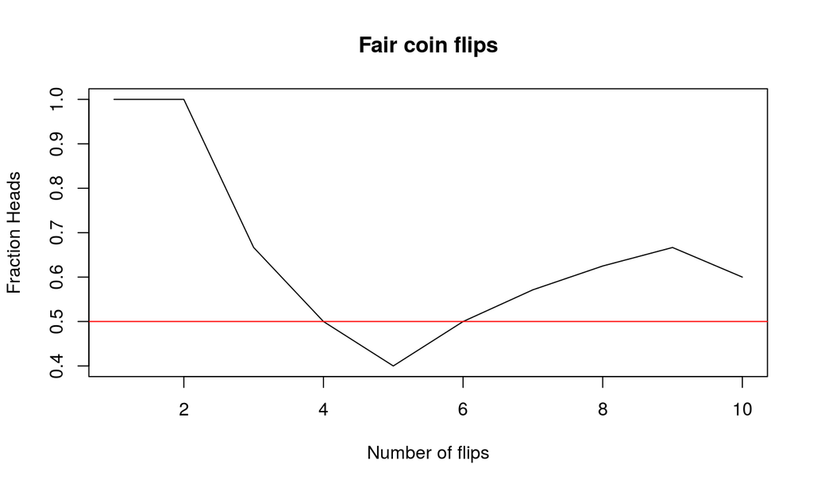

## After 100 flips:

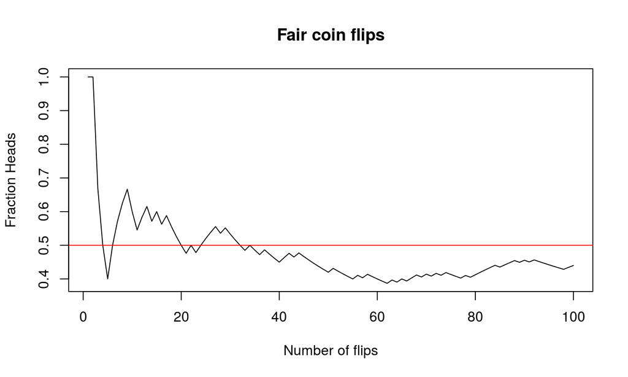

## After 1000 flips:

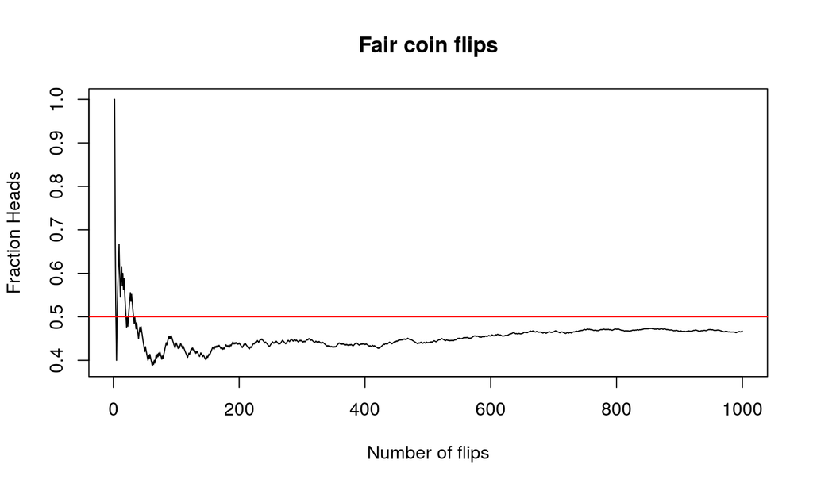

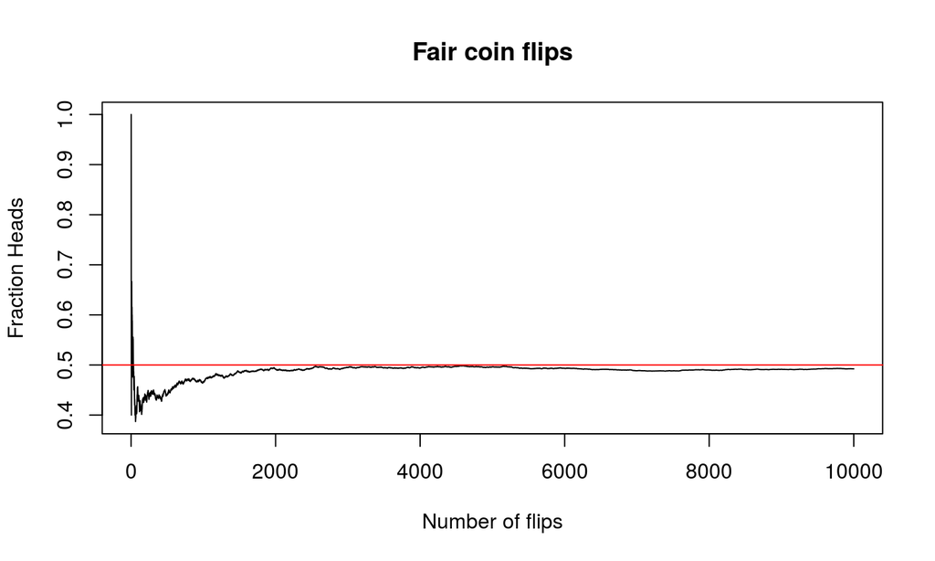

## Random Sampling:

### Random Sampling and large sample

### \(\xrightarrow{N\rightarrow\infty}\)

### (1) Sample Mean \(\approx\) Population Mean

### (2) Uncertainty of Sample Mean \(\rightarrow 0\)

## Random Sampling:

If we wanted to know: what is ideal temperature you keep thermostat?

**population**: all students at UBC

**sample**: students in this class who didn't wear a coat today

### Where does this go wrong?

## Sampling Error:

**sampling error**:

The difference between the value of the measure for the sample and the true value of the measure for the population

## Sampling Error vs. Measurement Error:

**Measurement Error**:

- Incorrectly describe the world because you **incorrectly** observe the cases you study
- e.g.: measure "Racism" by asking people "are you racist?"

**Sampling Error**:

- Incorrectly describe the world because **cases you study** are different from the population you want to learn about
- e.g.: you want to measure anti-immigration sentiment in Canada by interviewing Canadian university students
- Sample deviates from population **in a manner related to what you study**

## Sampling Error:

Types:

1. **Random Sampling Error**:
   - Error caused by random process of selecting samples
   - By chance, samples will be higher or lower than population average
   - **SOLUTION**: Sample more cases. Random errors get smaller as \(N \rightarrow \infty\)

## Sampling Error:

Imagine there are six people whose monthly incomes are:

1000, 1300, 1600, 1900, 2200, 2500

## Sampling Error:

Rather than asking all six, we take a sample of \(3\) at random and take the mean.

Our sample is: 1300, 1600, 2500

The sample mean is: 1800

The population mean is: 1750

## Sampling Error:

What if we took **all possible** samples of size \(3\)

| 1000 | 1300 | 1600 |
| --- | --- | --- |
| 1000 | 1300 | 1900 |
| 1000 | 1300 | 2200 |
| 1000 | 1300 | 2500 |
| 1000 | 1600 | 1300 |
| 1000 | 1600 | 1900 |
| 1000 | 1600 | 2200 |
| 1000 | 1600 | 2500 |
| 1000 | 1900 | 1300 |
| 1000 | 1900 | 1600 |
| 1000 | 1900 | 2200 |
| 1000 | 1900 | 2500 |
| 1000 | 2200 | 1300 |
| 1000 | 2200 | 1600 |
| 1000 | 2200 | 1900 |
| 1000 | 2200 | 2500 |
| 1000 | 2500 | 1300 |
| 1000 | 2500 | 1600 |
| 1000 | 2500 | 1900 |
| 1000 | 2500 | 2200 |
| 1300 | 1000 | 1600 |
| 1300 | 1000 | 1900 |
| 1300 | 1000 | 2200 |
| 1300 | 1000 | 2500 |
| 1300 | 1600 | 1000 |
| 1300 | 1600 | 1900 |
| 1300 | 1600 | 2200 |
| 1300 | 1600 | 2500 |
| 1300 | 1900 | 1000 |
| 1300 | 1900 | 1600 |
| 1300 | 1900 | 2200 |

[output cut: 89 more lines]

## Sampling Error:

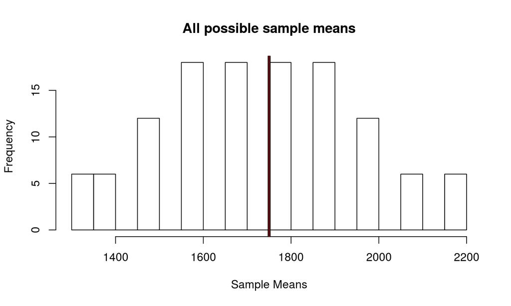

## Size of Random Sampling Error:

### Get's smaller as \(n\) gets larger

### at rate of \(1\over\sqrt{n}\)

## Size of Random Sampling Error:

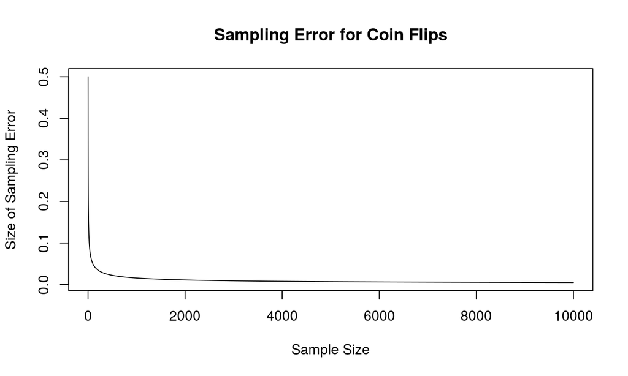

## Sampling Error:

Types:

1. **Sampling Bias**:
   - **sampling frame** or group from which you randomly sample \(\neq\) population
   - If you sample from group different from population you care about, you get bias
   - This means not every member of population has equal chance of being in sample

## Sampling Error:

### Sampling bias: sampling frame:

- Election poll based on sampling from phone book
- Survey on drug use sampling by list of home addresses

## Sampling Error:

Types:

1. **Sampling Bias**:
   - **self selection**: respondents/cases control whether they join the sample
   - Choice to join or not join the sample means not every member of population has equal chance of being in sample

## Sampling Error:

### Sampling bias: selection bias

What if…

- When bad news came out about Hillary, **Democrats** didn't want to answer the phone.
- When bad news came out about Trump, **Republicans** didn't want to answer the phone.